# Risk Factor Analysis

## Outcome Variable

**Outcome Variable:** ever_co

## Predictor Variables

**Intervention Variable:** nrooms

**Adjustment Set:**

- arm
- sex
- W_mage
- meducyrs
- feducyrs
- hhwealth_quart
- hfoodsec
- W_mhtcm
- W_mwtkg
- W_mbmi
- W_nchldlt5
- W_parity
- impfloor
- impsan
- safeh20
- delta_W_mage
- delta_meducyrs
- delta_feducyrs
- delta_hhwealth_quart
- delta_hfoodsec
- delta_W_mhtcm
- delta_W_mwtkg
- delta_W_mbmi
- delta_W_nchldlt5
- delta_W_parity
- delta_impfloor
- delta_impsan
- delta_safeh20

## Stratifying Variables

The analysis was stratified on these variable(s):

- agecat
- studyid
- country

## Data Summary

| agecat | studyid | country | nrooms | ever_co | n_cell | n |
| --- | --- | --- | --- | --- | --- | --- |
| 0-24 months | CMC-V-BCS-2002 | INDIA | 4+ | 0 | 12 | 373 |
| 0-24 months | CMC-V-BCS-2002 | INDIA | 4+ | 1 | 2 | 373 |
| 0-24 months | CMC-V-BCS-2002 | INDIA | 1 | 0 | 149 | 373 |
| 0-24 months | CMC-V-BCS-2002 | INDIA | 1 | 1 | 53 | 373 |
| 0-24 months | CMC-V-BCS-2002 | INDIA | 2 | 0 | 83 | 373 |
| 0-24 months | CMC-V-BCS-2002 | INDIA | 2 | 1 | 23 | 373 |
| 0-24 months | CMC-V-BCS-2002 | INDIA | 3 | 0 | 43 | 373 |
| 0-24 months | CMC-V-BCS-2002 | INDIA | 3 | 1 | 8 | 373 |
| 0-24 months | COHORTS | INDIA | 4+ | 0 | 105 | 5364 |
| 0-24 months | COHORTS | INDIA | 4+ | 1 | 1 | 5364 |
| 0-24 months | COHORTS | INDIA | 1 | 0 | 3081 | 5364 |
| 0-24 months | COHORTS | INDIA | 1 | 1 | 429 | 5364 |
| 0-24 months | COHORTS | INDIA | 2 | 0 | 1465 | 5364 |
| 0-24 months | COHORTS | INDIA | 2 | 1 | 88 | 5364 |
| 0-24 months | COHORTS | INDIA | 3 | 0 | 188 | 5364 |
| 0-24 months | COHORTS | INDIA | 3 | 1 | 7 | 5364 |
| 0-24 months | CONTENT | PERU | 4+ | 0 | 78 | 215 |
| 0-24 months | CONTENT | PERU | 4+ | 1 | 0 | 215 |
| 0-24 months | CONTENT | PERU | 1 | 0 | 44 | 215 |
| 0-24 months | CONTENT | PERU | 1 | 1 | 0 | 215 |
| 0-24 months | CONTENT | PERU | 2 | 0 | 54 | 215 |
| 0-24 months | CONTENT | PERU | 2 | 1 | 0 | 215 |
| 0-24 months | CONTENT | PERU | 3 | 0 | 39 | 215 |
| 0-24 months | CONTENT | PERU | 3 | 1 | 0 | 215 |
| 0-24 months | GMS-Nepal | NEPAL | 4+ | 0 | 216 | 686 |
| 0-24 months | GMS-Nepal | NEPAL | 4+ | 1 | 98 | 686 |
| 0-24 months | GMS-Nepal | NEPAL | 1 | 0 | 34 | 686 |
| 0-24 months | GMS-Nepal | NEPAL | 1 | 1 | 15 | 686 |
| 0-24 months | GMS-Nepal | NEPAL | 2 | 0 | 102 | 686 |
| 0-24 months | GMS-Nepal | NEPAL | 2 | 1 | 41 | 686 |

[output cut: 354 more lines]

The following strata were considered:

- agecat: 0-24 months, studyid: CMC-V-BCS-2002, country: INDIA
- agecat: 0-24 months, studyid: COHORTS, country: INDIA
- agecat: 0-24 months, studyid: CONTENT, country: PERU
- agecat: 0-24 months, studyid: GMS-Nepal, country: NEPAL
- agecat: 0-24 months, studyid: IRC, country: INDIA
- agecat: 0-24 months, studyid: JiVitA-3, country: BANGLADESH
- agecat: 0-24 months, studyid: JiVitA-4, country: BANGLADESH
- agecat: 0-24 months, studyid: MAL-ED, country: BANGLADESH
- agecat: 0-24 months, studyid: MAL-ED, country: BRAZIL
- agecat: 0-24 months, studyid: MAL-ED, country: INDIA
- agecat: 0-24 months, studyid: MAL-ED, country: NEPAL
- agecat: 0-24 months, studyid: MAL-ED, country: PERU
- agecat: 0-24 months, studyid: MAL-ED, country: SOUTH AFRICA
- agecat: 0-24 months, studyid: MAL-ED, country: TANZANIA, UNITED REPUBLIC OF
- agecat: 0-24 months, studyid: NIH-Crypto, country: BANGLADESH
- agecat: 0-24 months, studyid: PROVIDE, country: BANGLADESH
- agecat: 0-6 months, studyid: CMC-V-BCS-2002, country: INDIA
- agecat: 0-6 months, studyid: COHORTS, country: INDIA
- agecat: 0-6 months, studyid: CONTENT, country: PERU
- agecat: 0-6 months, studyid: GMS-Nepal, country: NEPAL
- agecat: 0-6 months, studyid: IRC, country: INDIA
- agecat: 0-6 months, studyid: JiVitA-3, country: BANGLADESH
- agecat: 0-6 months, studyid: JiVitA-4, country: BANGLADESH
- agecat: 0-6 months, studyid: MAL-ED, country: BANGLADESH
- agecat: 0-6 months, studyid: MAL-ED, country: BRAZIL
- agecat: 0-6 months, studyid: MAL-ED, country: INDIA
- agecat: 0-6 months, studyid: MAL-ED, country: NEPAL
- agecat: 0-6 months, studyid: MAL-ED, country: PERU
- agecat: 0-6 months, studyid: MAL-ED, country: SOUTH AFRICA
- agecat: 0-6 months, studyid: MAL-ED, country: TANZANIA, UNITED REPUBLIC OF
- agecat: 0-6 months, studyid: NIH-Crypto, country: BANGLADESH
- agecat: 0-6 months, studyid: PROVIDE, country: BANGLADESH
- agecat: 6-24 months, studyid: CMC-V-BCS-2002, country: INDIA
- agecat: 6-24 months, studyid: COHORTS, country: INDIA
- agecat: 6-24 months, studyid: CONTENT, country: PERU
- agecat: 6-24 months, studyid: GMS-Nepal, country: NEPAL
- agecat: 6-24 months, studyid: IRC, country: INDIA
- agecat: 6-24 months, studyid: JiVitA-3, country: BANGLADESH
- agecat: 6-24 months, studyid: JiVitA-4, country: BANGLADESH
- agecat: 6-24 months, studyid: MAL-ED, country: BANGLADESH
- agecat: 6-24 months, studyid: MAL-ED, country: BRAZIL
- agecat: 6-24 months, studyid: MAL-ED, country: INDIA
- agecat: 6-24 months, studyid: MAL-ED, country: NEPAL
- agecat: 6-24 months, studyid: MAL-ED, country: PERU
- agecat: 6-24 months, studyid: MAL-ED, country: SOUTH AFRICA
- agecat: 6-24 months, studyid: MAL-ED, country: TANZANIA, UNITED REPUBLIC OF
- agecat: 6-24 months, studyid: NIH-Crypto, country: BANGLADESH
- agecat: 6-24 months, studyid: PROVIDE, country: BANGLADESH

### Dropped Strata

Some strata were dropped due to rare outcomes:

- agecat: 0-24 months, studyid: CMC-V-BCS-2002, country: INDIA
- agecat: 0-24 months, studyid: COHORTS, country: INDIA
- agecat: 0-24 months, studyid: CONTENT, country: PERU
- agecat: 0-24 months, studyid: IRC, country: INDIA
- agecat: 0-24 months, studyid: MAL-ED, country: BANGLADESH
- agecat: 0-24 months, studyid: MAL-ED, country: BRAZIL
- agecat: 0-24 months, studyid: MAL-ED, country: INDIA
- agecat: 0-24 months, studyid: MAL-ED, country: NEPAL
- agecat: 0-24 months, studyid: MAL-ED, country: PERU
- agecat: 0-24 months, studyid: MAL-ED, country: SOUTH AFRICA
- agecat: 0-24 months, studyid: MAL-ED, country: TANZANIA, UNITED REPUBLIC OF
- agecat: 0-24 months, studyid: PROVIDE, country: BANGLADESH
- agecat: 0-6 months, studyid: CMC-V-BCS-2002, country: INDIA
- agecat: 0-6 months, studyid: COHORTS, country: INDIA
- agecat: 0-6 months, studyid: CONTENT, country: PERU
- agecat: 0-6 months, studyid: GMS-Nepal, country: NEPAL
- agecat: 0-6 months, studyid: IRC, country: INDIA
- agecat: 0-6 months, studyid: MAL-ED, country: BANGLADESH
- agecat: 0-6 months, studyid: MAL-ED, country: BRAZIL
- agecat: 0-6 months, studyid: MAL-ED, country: INDIA
- agecat: 0-6 months, studyid: MAL-ED, country: NEPAL
- agecat: 0-6 months, studyid: MAL-ED, country: PERU
- agecat: 0-6 months, studyid: MAL-ED, country: SOUTH AFRICA
- agecat: 0-6 months, studyid: MAL-ED, country: TANZANIA, UNITED REPUBLIC OF
- agecat: 0-6 months, studyid: NIH-Crypto, country: BANGLADESH
- agecat: 0-6 months, studyid: PROVIDE, country: BANGLADESH
- agecat: 6-24 months, studyid: CMC-V-BCS-2002, country: INDIA
- agecat: 6-24 months, studyid: COHORTS, country: INDIA
- agecat: 6-24 months, studyid: CONTENT, country: PERU
- agecat: 6-24 months, studyid: IRC, country: INDIA
- agecat: 6-24 months, studyid: MAL-ED, country: BANGLADESH
- agecat: 6-24 months, studyid: MAL-ED, country: BRAZIL
- agecat: 6-24 months, studyid: MAL-ED, country: INDIA
- agecat: 6-24 months, studyid: MAL-ED, country: NEPAL
- agecat: 6-24 months, studyid: MAL-ED, country: PERU
- agecat: 6-24 months, studyid: MAL-ED, country: SOUTH AFRICA
- agecat: 6-24 months, studyid: MAL-ED, country: TANZANIA, UNITED REPUBLIC OF
- agecat: 6-24 months, studyid: PROVIDE, country: BANGLADESH

## Methods Detail

We’re interested in the causal parameters $E[Y_a]$ for all values of $a \in \mathcal{A}$. These parameters represent the mean outcome if, possibly contrary to fact, we intervened to set all units to have $A=a$. Under the randomization and positivity assumptions, these are identified by the statistical parameters $\psi_a=E_W[E_{Y|A,W}(Y|A=a,W)]$. In addition, we’re interested in the mean of $Y$, $E[Y]$ under no intervention (the observed mean). We will estimate these parameters by using SuperLearner to fit the relevant likelihood factors – $E_{Y|A,W}(Y|A=a,W)$ and $p(A=a|W)$, and then updating our likelihood fit using a joint TMLE.

For unadjusted analyses ($W=\{\}$), initial likelihoods were estimated using Lrnr_glm to estimate the simple $E(Y|A)$ and Lrnr_mean to estimate $p(A)$. For adjusted analyses, a small library containing Lrnr_glmnet, Lrnr_xgboost, and Lrnr_mean was used.

Having estimated these parameters, we will then use the delta method to estimate relative risks and attributable risks relative to a prespecified baseline level of $A$.

# Results Detail

## Results Plots

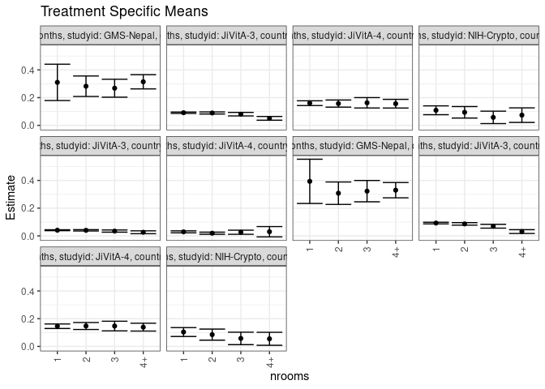

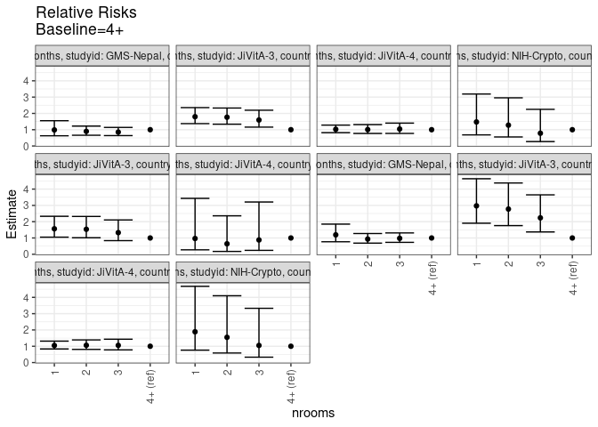

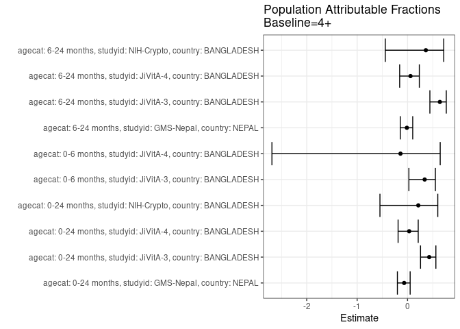

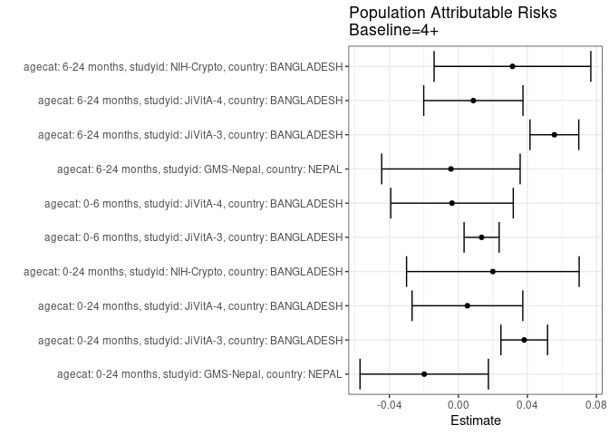

## Results Table

### Parameter: TSM

| agecat | studyid | country | intervention_level | baseline_level | estimate | ci_lower | ci_upper |
| --- | --- | --- | --- | --- | --- | --- | --- |
| 0-24 months | GMS-Nepal | NEPAL | 4+ | NA | 0.3142546 | 0.2629032 | 0.3656060 |
| 0-24 months | GMS-Nepal | NEPAL | 1 | NA | 0.3101672 | 0.1792062 | 0.4411281 |
| 0-24 months | GMS-Nepal | NEPAL | 2 | NA | 0.2822695 | 0.2083376 | 0.3562014 |
| 0-24 months | GMS-Nepal | NEPAL | 3 | NA | 0.2679436 | 0.2031325 | 0.3327547 |
| 0-24 months | JiVitA-3 | BANGLADESH | 4+ | NA | 0.0506480 | 0.0371320 | 0.0641639 |
| 0-24 months | JiVitA-3 | BANGLADESH | 1 | NA | 0.0910765 | 0.0860968 | 0.0960562 |
| 0-24 months | JiVitA-3 | BANGLADESH | 2 | NA | 0.0894631 | 0.0819117 | 0.0970144 |
| 0-24 months | JiVitA-3 | BANGLADESH | 3 | NA | 0.0808053 | 0.0681804 | 0.0934303 |
| 0-24 months | JiVitA-4 | BANGLADESH | 4+ | NA | 0.1561971 | 0.1249135 | 0.1874806 |
| 0-24 months | JiVitA-4 | BANGLADESH | 1 | NA | 0.1600354 | 0.1428113 | 0.1772594 |
| 0-24 months | JiVitA-4 | BANGLADESH | 2 | NA | 0.1571228 | 0.1314242 | 0.1828214 |
| 0-24 months | JiVitA-4 | BANGLADESH | 3 | NA | 0.1627990 | 0.1254769 | 0.2001211 |
| 0-24 months | NIH-Crypto | BANGLADESH | 4+ | NA | 0.0736842 | 0.0211140 | 0.1262544 |
| 0-24 months | NIH-Crypto | BANGLADESH | 1 | NA | 0.1086957 | 0.0768735 | 0.1405178 |
| 0-24 months | NIH-Crypto | BANGLADESH | 2 | NA | 0.0942408 | 0.0527794 | 0.1357022 |
| 0-24 months | NIH-Crypto | BANGLADESH | 3 | NA | 0.0576923 | 0.0128515 | 0.1025331 |
| 0-6 months | JiVitA-3 | BANGLADESH | 4+ | NA | 0.0261760 | 0.0158116 | 0.0365404 |
| 0-6 months | JiVitA-3 | BANGLADESH | 1 | NA | 0.0409477 | 0.0376202 | 0.0442752 |
| 0-6 months | JiVitA-3 | BANGLADESH | 2 | NA | 0.0401690 | 0.0353759 | 0.0449621 |
| 0-6 months | JiVitA-3 | BANGLADESH | 3 | NA | 0.0347599 | 0.0269038 | 0.0426160 |
| 0-6 months | JiVitA-4 | BANGLADESH | 4+ | NA | 0.0300752 | -0.0071104 | 0.0672608 |
| 0-6 months | JiVitA-4 | BANGLADESH | 1 | NA | 0.0290873 | 0.0219427 | 0.0362318 |
| 0-6 months | JiVitA-4 | BANGLADESH | 2 | NA | 0.0193498 | 0.0117793 | 0.0269204 |
| 0-6 months | JiVitA-4 | BANGLADESH | 3 | NA | 0.0264151 | 0.0116483 | 0.0411818 |
| 6-24 months | GMS-Nepal | NEPAL | 4+ | NA | 0.3297437 | 0.2745627 | 0.3849247 |
| 6-24 months | GMS-Nepal | NEPAL | 1 | NA | 0.3933748 | 0.2338363 | 0.5529134 |
| 6-24 months | GMS-Nepal | NEPAL | 2 | NA | 0.3078131 | 0.2269269 | 0.3886992 |
| 6-24 months | GMS-Nepal | NEPAL | 3 | NA | 0.3227401 | 0.2459337 | 0.3995465 |
| 6-24 months | JiVitA-3 | BANGLADESH | 4+ | NA | 0.0311562 | 0.0174555 | 0.0448570 |
| 6-24 months | JiVitA-3 | BANGLADESH | 1 | NA | 0.0925790 | 0.0866036 | 0.0985544 |
| 6-24 months | JiVitA-3 | BANGLADESH | 2 | NA | 0.0864565 | 0.0773608 | 0.0955521 |
| 6-24 months | JiVitA-3 | BANGLADESH | 3 | NA | 0.0696586 | 0.0558534 | 0.0834637 |
| 6-24 months | JiVitA-4 | BANGLADESH | 4+ | NA | 0.1390513 | 0.1107549 | 0.1673477 |
| 6-24 months | JiVitA-4 | BANGLADESH | 1 | NA | 0.1456481 | 0.1293109 | 0.1619852 |
| 6-24 months | JiVitA-4 | BANGLADESH | 2 | NA | 0.1473039 | 0.1221935 | 0.1724143 |
| 6-24 months | JiVitA-4 | BANGLADESH | 3 | NA | 0.1468312 | 0.1118837 | 0.1817786 |
| 6-24 months | NIH-Crypto | BANGLADESH | 4+ | NA | 0.0549451 | 0.0080942 | 0.1017960 |
| 6-24 months | NIH-Crypto | BANGLADESH | 1 | NA | 0.1037464 | 0.0716406 | 0.1358522 |
| 6-24 months | NIH-Crypto | BANGLADESH | 2 | NA | 0.0851064 | 0.0451917 | 0.1250211 |
| 6-24 months | NIH-Crypto | BANGLADESH | 3 | NA | 0.0576923 | 0.0128504 | 0.1025342 |

### Parameter: E(Y)

| agecat | studyid | country | intervention_level | baseline_level | estimate | ci_lower | ci_upper |
| --- | --- | --- | --- | --- | --- | --- | --- |
| 0-24 months | GMS-Nepal | NEPAL | NA | NA | 0.2944606 | 0.2603274 | 0.3285938 |
| 0-24 months | JiVitA-3 | BANGLADESH | NA | NA | 0.0888335 | 0.0849259 | 0.0927411 |
| 0-24 months | JiVitA-4 | BANGLADESH | NA | NA | 0.1614449 | 0.1501252 | 0.1727646 |
| 0-24 months | NIH-Crypto | BANGLADESH | NA | NA | 0.0936675 | 0.0729118 | 0.1144233 |
| 0-6 months | JiVitA-3 | BANGLADESH | NA | NA | 0.0396476 | 0.0371448 | 0.0421504 |
| 0-6 months | JiVitA-4 | BANGLADESH | NA | NA | 0.0263831 | 0.0210411 | 0.0317252 |
| 6-24 months | GMS-Nepal | NEPAL | NA | NA | 0.3254237 | 0.2875855 | 0.3632619 |
| 6-24 months | JiVitA-3 | BANGLADESH | NA | NA | 0.0868080 | 0.0821483 | 0.0914677 |
| 6-24 months | JiVitA-4 | BANGLADESH | NA | NA | 0.1477315 | 0.1371478 | 0.1583151 |
| 6-24 months | NIH-Crypto | BANGLADESH | NA | NA | 0.0863014 | 0.0659171 | 0.1066856 |

### Parameter: RR

| agecat | studyid | country | intervention_level | baseline_level | estimate | ci_lower | ci_upper |
| --- | --- | --- | --- | --- | --- | --- | --- |
| 0-24 months | GMS-Nepal | NEPAL | 4+ | 4+ | 1.0000000 | 1.0000000 | 1.000000 |
| 0-24 months | GMS-Nepal | NEPAL | 1 | 4+ | 0.9869933 | 0.6276441 | 1.552083 |
| 0-24 months | GMS-Nepal | NEPAL | 2 | 4+ | 0.8982192 | 0.6602835 | 1.221896 |
| 0-24 months | GMS-Nepal | NEPAL | 3 | 4+ | 0.8526323 | 0.6372433 | 1.140823 |
| 0-24 months | JiVitA-3 | BANGLADESH | 4+ | 4+ | 1.0000000 | 1.0000000 | 1.000000 |
| 0-24 months | JiVitA-3 | BANGLADESH | 1 | 4+ | 1.7982247 | 1.3726052 | 2.355821 |
| 0-24 months | JiVitA-3 | BANGLADESH | 2 | 4+ | 1.7663692 | 1.3390173 | 2.330112 |
| 0-24 months | JiVitA-3 | BANGLADESH | 3 | 4+ | 1.5954300 | 1.1595384 | 2.195181 |
| 0-24 months | JiVitA-4 | BANGLADESH | 4+ | 4+ | 1.0000000 | 1.0000000 | 1.000000 |
| 0-24 months | JiVitA-4 | BANGLADESH | 1 | 4+ | 1.0245734 | 0.8186048 | 1.282366 |
| 0-24 months | JiVitA-4 | BANGLADESH | 2 | 4+ | 1.0059268 | 0.7706155 | 1.313092 |
| 0-24 months | JiVitA-4 | BANGLADESH | 3 | 4+ | 1.0422668 | 0.7736240 | 1.404197 |
| 0-24 months | NIH-Crypto | BANGLADESH | 4+ | 4+ | 1.0000000 | 1.0000000 | 1.000000 |
| 0-24 months | NIH-Crypto | BANGLADESH | 1 | 4+ | 1.4751553 | 0.6822075 | 3.189767 |
| 0-24 months | NIH-Crypto | BANGLADESH | 2 | 4+ | 1.2789828 | 0.5531474 | 2.957254 |
| 0-24 months | NIH-Crypto | BANGLADESH | 3 | 4+ | 0.7829670 | 0.2726112 | 2.248761 |
| 0-6 months | JiVitA-3 | BANGLADESH | 4+ | 4+ | 1.0000000 | 1.0000000 | 1.000000 |
| 0-6 months | JiVitA-3 | BANGLADESH | 1 | 4+ | 1.5643234 | 1.0496219 | 2.331418 |
| 0-6 months | JiVitA-3 | BANGLADESH | 2 | 4+ | 1.5345752 | 1.0140700 | 2.322247 |
| 0-6 months | JiVitA-3 | BANGLADESH | 3 | 4+ | 1.3279299 | 0.8368019 | 2.107306 |
| 0-6 months | JiVitA-4 | BANGLADESH | 4+ | 4+ | 1.0000000 | 1.0000000 | 1.000000 |
| 0-6 months | JiVitA-4 | BANGLADESH | 1 | 4+ | 0.9671515 | 0.2726685 | 3.430473 |
| 0-6 months | JiVitA-4 | BANGLADESH | 2 | 4+ | 0.6433824 | 0.1753735 | 2.360339 |
| 0-6 months | JiVitA-4 | BANGLADESH | 3 | 4+ | 0.8783019 | 0.2404209 | 3.208598 |
| 6-24 months | GMS-Nepal | NEPAL | 4+ | 4+ | 1.0000000 | 1.0000000 | 1.000000 |
| 6-24 months | GMS-Nepal | NEPAL | 1 | 4+ | 1.1929716 | 0.7689204 | 1.850882 |
| 6-24 months | GMS-Nepal | NEPAL | 2 | 4+ | 0.9334920 | 0.6840240 | 1.273942 |
| 6-24 months | GMS-Nepal | NEPAL | 3 | 4+ | 0.9787605 | 0.7316796 | 1.309278 |
| 6-24 months | JiVitA-3 | BANGLADESH | 4+ | 4+ | 1.0000000 | 1.0000000 | 1.000000 |
| 6-24 months | JiVitA-3 | BANGLADESH | 1 | 4+ | 2.9714429 | 1.9050265 | 4.634829 |
| 6-24 months | JiVitA-3 | BANGLADESH | 2 | 4+ | 2.7749317 | 1.7602945 | 4.374408 |
| 6-24 months | JiVitA-3 | BANGLADESH | 3 | 4+ | 2.2357812 | 1.3704283 | 3.647558 |
| 6-24 months | JiVitA-4 | BANGLADESH | 4+ | 4+ | 1.0000000 | 1.0000000 | 1.000000 |
| 6-24 months | JiVitA-4 | BANGLADESH | 1 | 4+ | 1.0474412 | 0.8343392 | 1.314972 |
| 6-24 months | JiVitA-4 | BANGLADESH | 2 | 4+ | 1.0593490 | 0.8069322 | 1.390724 |
| 6-24 months | JiVitA-4 | BANGLADESH | 3 | 4+ | 1.0559494 | 0.7778049 | 1.433559 |
| 6-24 months | NIH-Crypto | BANGLADESH | 4+ | 4+ | 1.0000000 | 1.0000000 | 1.000000 |
| 6-24 months | NIH-Crypto | BANGLADESH | 1 | 4+ | 1.8881844 | 0.7622425 | 4.677305 |
| 6-24 months | NIH-Crypto | BANGLADESH | 2 | 4+ | 1.5489362 | 0.5853251 | 4.098924 |
| 6-24 months | NIH-Crypto | BANGLADESH | 3 | 4+ | 1.0500000 | 0.3312144 | 3.328660 |

### Parameter: PAR

| agecat | studyid | country | intervention_level | baseline_level | estimate | ci_lower | ci_upper |
| --- | --- | --- | --- | --- | --- | --- | --- |
| 0-24 months | GMS-Nepal | NEPAL | 4+ | NA | -0.0197939 | -0.0570022 | 0.0174143 |
| 0-24 months | JiVitA-3 | BANGLADESH | 4+ | NA | 0.0381855 | 0.0246776 | 0.0516934 |
| 0-24 months | JiVitA-4 | BANGLADESH | 4+ | NA | 0.0052478 | -0.0268424 | 0.0373381 |
| 0-24 months | NIH-Crypto | BANGLADESH | 4+ | NA | 0.0199833 | -0.0300336 | 0.0700003 |
| 0-6 months | JiVitA-3 | BANGLADESH | 4+ | NA | 0.0134716 | 0.0033148 | 0.0236284 |
| 0-6 months | JiVitA-4 | BANGLADESH | 4+ | NA | -0.0036920 | -0.0391994 | 0.0318154 |
| 6-24 months | GMS-Nepal | NEPAL | 4+ | NA | -0.0043199 | -0.0444523 | 0.0358124 |
| 6-24 months | JiVitA-3 | BANGLADESH | 4+ | NA | 0.0556517 | 0.0415226 | 0.0697808 |
| 6-24 months | JiVitA-4 | BANGLADESH | 4+ | NA | 0.0086801 | -0.0200801 | 0.0374404 |
| 6-24 months | NIH-Crypto | BANGLADESH | 4+ | NA | 0.0313563 | -0.0140670 | 0.0767796 |

### Parameter: PAF

| agecat | studyid | country | intervention_level | baseline_level | estimate | ci_lower | ci_upper |
| --- | --- | --- | --- | --- | --- | --- | --- |
| 0-24 months | GMS-Nepal | NEPAL | 4+ | NA | -0.0672210 | -0.2013349 | 0.0519208 |
| 0-24 months | JiVitA-3 | BANGLADESH | 4+ | NA | 0.4298549 | 0.2575819 | 0.5621532 |
| 0-24 months | JiVitA-4 | BANGLADESH | 4+ | NA | 0.0325055 | -0.1874795 | 0.2117374 |
| 0-24 months | NIH-Crypto | BANGLADESH | 4+ | NA | 0.2133432 | -0.5474483 | 0.6000972 |
| 0-6 months | JiVitA-3 | BANGLADESH | 4+ | NA | 0.3397836 | 0.0267239 | 0.5521458 |
| 0-6 months | JiVitA-4 | BANGLADESH | 4+ | NA | -0.1399394 | -2.6903450 | 0.6478752 |
| 6-24 months | GMS-Nepal | NEPAL | 4+ | NA | -0.0132748 | -0.1444262 | 0.1028466 |
| 6-24 months | JiVitA-3 | BANGLADESH | 4+ | NA | 0.6410900 | 0.4433290 | 0.7685951 |
| 6-24 months | JiVitA-4 | BANGLADESH | 4+ | NA | 0.0587562 | -0.1563953 | 0.2338780 |
| 6-24 months | NIH-Crypto | BANGLADESH | 4+ | NA | 0.3633351 | -0.4411875 | 0.7187443 |